# R Stats Notebook

Most analyses assume a normal distribution of the data. While linear models are robust to this assumption, it is difficult to guage exactly how robust it is.

The data can be transformed, but transformations don’t always work to make data fit normality.

**Generalized Linear Modeling (GLM)** allows the assumption of differing underlying distributions of the data, such as a Poisson distribution or a Logistic distribution.

**Logistic Regression** is used when the response variable is binary.

**Poisson Regression** is used when the response variable represents *count data*.

**Negative Binomial** can also be used with right-skewed data when variance is substantially higher than the mean.

##### GLM vs. LM

Least squares estimation no longer applies, maximum likelihood methods are used

### Generalized Linear Modeling

A GLM consists of 3 components:  
- a random component  
- a systematic component  
- a link function

The **random component** is the response variable and its distribution.

The **systematic component** represents the predictors in the model.  
- may be continuous and/or categorical  
- may include interactions

GLM distribution *must* be within the **exponential distribution family**.  
- Normal  
- Binomial  
- Poisson  
- Gamma  
- Negative Binomial  
- More

#### Maximum Likelihood Estimation

General method for statistical estimation of specific parameters in the model.

**Rationale**: given a sample of observations from a population, we find the estimates of one (or more) parameter(s) that maximuze the likelihood of observing those data **given a specified model**.

**ML vs. OLS estimation:** **For ML**: point and interval estimation (mean & SE) of parameters relies on distributional assumptions (i.e. MUST specify a probability distribution).

**OLS**: point estimates require no disal assumption.

The **type of data** determines the appropriate distribution to use in modeling  
If response variable is..  
- continuouse: Normal distribution  
- binary: Binomial  
- counts: Poisson

Probability distributions from exponential family can be defined by two parameters:  
1. Natural parameters (a function of the mean)  
2. Dispersion parameter (function of the variance)

**Binomial and Poisson**  
Variance is related to the mean and dispersion parameter is set to 1:  
- Poisson: variance = mean  
- Binomial: variance <= mean (typically less)

### Logistic Regression

Used to model response variables taht are binary (presence/absence, alive/dead).

Predictors can be either continuous and/or categorical.

Model output is a *probability* of the response.

When the response is binary (categorical w/ two levels, 0 and 1), we actually model π(x), the probability that Y=1 for a given value of X.  
Error terms from a logistic model are not normally distributed; therefore Ordinary Least Squares (OLS) is not appropriate, and maximum likelihood is used.  
For logistic regression, π(x) is transformed to make the logistic model resemble linearity. To do this, the π(x) is transfered into **odds**.

```r
data = read.csv("uta.csv") # load in data

# make the model
logit <- glm(uta ~ p_a, family = binomial(link = logit), data = data)
# family = the distribution of the data
# link is how to link the distribution
summary(logit)
```

```
Call:
glm(formula = uta ~ p_a, family = binomial(link = logit), data = data)

Coefficients:
            Estimate Std. Error z value Pr(>|z|)
(Intercept)   3.6061     1.6953   2.127   0.0334 *
p_a          -0.2196     0.1005  -2.184   0.0289 *
---
Signif. codes:  0 ‘***’ 0.001 ‘**’ 0.01 ‘*’ 0.05 ‘.’ 0.1 ‘ ’ 1

(Dispersion parameter for binomial family taken to be 1)

    Null deviance: 26.287  on 18  degrees of freedom
Residual deviance: 14.221  on 17  degrees of freedom
AIC: 18.221

Number of Fisher Scoring iterations: 6
```

```r
exp(-0.2196) # aids in interpretation
```

```
[1] 0.8028399
```

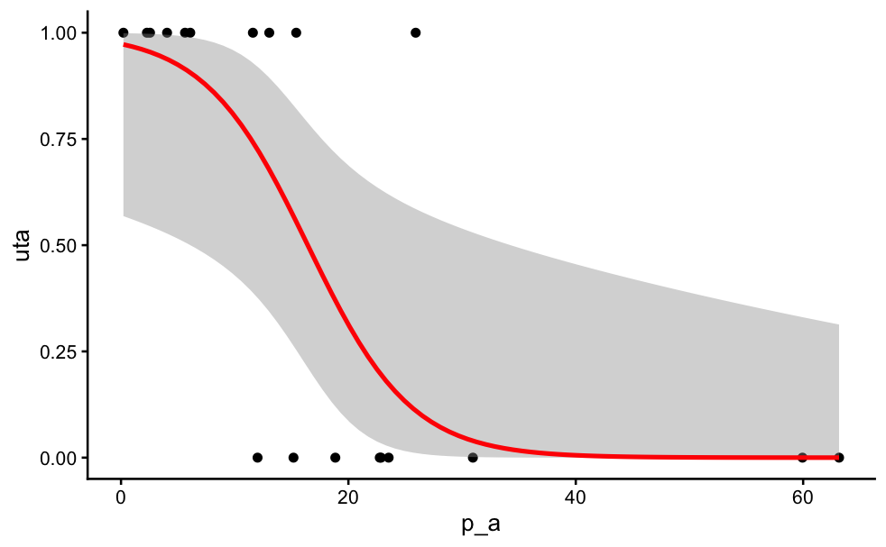

```r
library(ggplot2)
ggplot(data, aes(x = p_a, y = uta)) +
  geom_point() +
  # stat_smooth() adds the model line
  stat_smooth(method = "glm", color = "red", se = T,
              method.args = list(family = binomial)) +
  theme_classic()
```

#### Null Hypothesis and Model Fitting

Two common ways to test H0: 1. Calculate the Wald statistic (a ML version of a t-test) 2. Use a Likelihood Ratio test of the full model to the reduced model

The p-value and z-statistic given in the standard ‘summary()’ output used the Wald statistic (compared to a normal z-distribution…hence the z-statistic)

Wald most reliable when sample sizes are learge…less reliale and lacks power when sample sizes are smaller.

```r
drop1(logit, test = "Chi")
```

```
Single term deletions

Model:
uta ~ p_a
       Df Deviance    AIC    LRT  Pr(>Chi)
<none>      14.221 18.221
p_a     1   26.287 28.287 12.066 0.0005134 ***
---
Signif. codes:  0 ‘***’ 0.001 ‘**’ 0.01 ‘*’ 0.05 ‘.’ 0.1 ‘ ’ 1
```

Compares the full model to a reduced model excluding the predictor, calculates the log-Likelihood of each model, and compares them.

We use the log-Likelihood of each model to calculate the Likelihood Ratio Test statistic.

The sampling distribution of this statitstic is very similar to a Chi=square distribution with 1 degree of freedom.

### Poisson Regression

Used when observations are *count* data.

Examples:  
- Number of eggs in a clutch that hatch  
- Number of infected plants in transects

Common quality of these data is that 0 is often the mode, 1 is the next most common, 2 the next, and so on…

Count data often approximate a poisson distribution.  
- the mean equals the variance  
A traditional method to deal with count data is to transform using a power transformation  
- tends to remove the relationship b/w mean and viariance

Alternative is to use a GLM with a poisson error term and log link function (sometimes called a **log-linear models**.)

This model is expressed as:

```r
log(u) = B[0] + B[1]*x
```

Model predicts that a single unit increase in X results in Y increasing by a factor of e^B[1]

The sign B[1] represents Y increasing or decreasing as X increases.

Mosgt everything we learned about logistic regression applies to a poisson regression.

**Common Problem when modeling count data**

We are assuming that the dependent variable has a poisson distribution where the mean eaquals the variance.  
Often the variance exceeds the mean  
- this is called **overdispersion**

**How to deal with overdispersion?**  
1. Can correct standard errors after the fact, using a formula  
2. Use a more appropriate probability distribution to model the data (negative binomial)

A negative binoial model addresses overdispersion by including estimation of dispersion parameter and relaxes the assumption of equal mean and variance.

3. Use “quasi-likelihood” methods that estimate the dispersion parameter from the data rather than restricting it as defined by the Poisson model
- use this if overdispersion is small

```r
gotelli <- read.csv("gotelli.csv")

# Predictors measured on very different scales, so they should be centered to avoid obvious collinearity issues. Calculate z-scores:
gotelli$cLatitude <- scale(gotelli$Latitude, scale = F)
gotelli$cElevation <- scale(gotelli$Elevation, scale = F)


# now run the model
gotelli.glm <- glm(Srich ~ Habitat * cLatitude * cElevation,
                   family = poisson, data = gotelli)

# MUST check dispersion assumptions
gotelli.glm$deviance/gotelli.glm$df.residual # if ~1, assumptions satisfied.
```

```
[1] 1.104765
```

```r
summary(gotelli.glm)
```

```
Call:
glm(formula = Srich ~ Habitat * cLatitude * cElevation, family = poisson,
    data = gotelli)

Coefficients:
                                     Estimate Std. Error z value
(Intercept)                         1.5237266  0.1044276  14.591
HabitatForest                       0.6284757  0.1292095   4.864
cLatitude                          -0.2257304  0.1059277  -2.131
cElevation                         -0.0006575  0.0006878  -0.956
HabitatForest:cLatitude            -0.0089115  0.1314652  -0.068
HabitatForest:cElevation           -0.0006053  0.0008531  -0.710
cLatitude:cElevation                0.0004718  0.0007208   0.655
HabitatForest:cLatitude:cElevation -0.0003348  0.0008941  -0.375
                                   Pr(>|z|)
(Intercept)                         < 2e-16 ***
HabitatForest                      1.15e-06 ***
cLatitude                            0.0331 *
cElevation                           0.3391
HabitatForest:cLatitude              0.9460
HabitatForest:cElevation             0.4780
cLatitude:cElevation                 0.5127
HabitatForest:cLatitude:cElevation   0.7080
---
Signif. codes:  0 ‘***’ 0.001 ‘**’ 0.01 ‘*’ 0.05 ‘.’ 0.1 ‘ ’ 1

(Dispersion parameter for poisson family taken to be 1)

    Null deviance: 102.763  on 43  degrees of freedom
Residual deviance:  39.772  on 36  degrees of freedom
AIC: 216.13

Number of Fisher Scoring iterations: 4
```

Our model is very complex, and thus hard to interpret. To make this easier, we will reduce our model.

```r
library(MASS)
# want to select the model with the LOWEST AIC score
stepAIC(gotelli.glm, trace = F) # gives best model
```

```
Call:  glm(formula = Srich ~ Habitat + cLatitude + cElevation, family = poisson,
    data = gotelli)

Coefficients:
  (Intercept)  HabitatForest      cLatitude     cElevation
     1.527436       0.635439      -0.235793      -0.001141

Degrees of Freedom: 43 Total (i.e. Null);  40 Residual
Null Deviance:      102.8
Residual Deviance: 40.69    AIC: 209
```

```r
stepAIC(gotelli.glm, trace = T) # gives ALL models
```

```
Start:  AIC=216.13
Srich ~ Habitat * cLatitude * cElevation

                               Df Deviance    AIC
- Habitat:cLatitude:cElevation  1   39.912 214.27
<none>                              39.772 216.13

Step:  AIC=214.27
Srich ~ Habitat + cLatitude + cElevation + Habitat:cLatitude +
    Habitat:cElevation + cLatitude:cElevation

                       Df Deviance    AIC
- Habitat:cLatitude     1   39.913 212.27
- cLatitude:cElevation  1   40.270 212.62
- Habitat:cElevation    1   40.290 212.64
<none>                      39.912 214.27

Step:  AIC=212.27
Srich ~ Habitat + cLatitude + cElevation + Habitat:cElevation +
    cLatitude:cElevation

                       Df Deviance    AIC
- cLatitude:cElevation  1   40.273 210.63
- Habitat:cElevation    1   40.330 210.68
<none>                      39.913 212.27

Step:  AIC=210.63
Srich ~ Habitat + cLatitude + cElevation + Habitat:cElevation

                     Df Deviance    AIC
- Habitat:cElevation  1   40.690 209.04
<none>                    40.273 210.63
- cLatitude           1   56.212 224.57

Step:  AIC=209.04
Srich ~ Habitat + cLatitude + cElevation

             Df Deviance    AIC
<none>            40.690 209.04
- cElevation  1   50.284 216.64
- cLatitude   1   56.649 223.00
- Habitat     1   70.376 236.73

Call:  glm(formula = Srich ~ Habitat + cLatitude + cElevation, family = poisson,
    data = gotelli)

Coefficients:
  (Intercept)  HabitatForest      cLatitude     cElevation
     1.527436       0.635439      -0.235793      -0.001141

Degrees of Freedom: 43 Total (i.e. Null);  40 Residual
Null Deviance:      102.8
Residual Deviance: 40.69    AIC: 209
```

Now with the best fit model, we need to examine the parameters within this model.

```r
gotelli.glm <- glm(Srich ~ Habitat + cLatitude + cElevation,
                   family = poisson, data = gotelli)

summary(gotelli.glm) # provides the Wald statistic
```

```
Call:
glm(formula = Srich ~ Habitat + cLatitude + cElevation, family = poisson,
    data = gotelli)

Coefficients:
                Estimate Std. Error z value Pr(>|z|)
(Intercept)    1.5274362  0.0985683  15.496  < 2e-16 ***
HabitatForest  0.6354389  0.1195664   5.315 1.07e-07 ***
cLatitude     -0.2357930  0.0616638  -3.824 0.000131 ***
cElevation    -0.0011411  0.0003749  -3.044 0.002337 **
---
Signif. codes:  0 ‘***’ 0.001 ‘**’ 0.01 ‘*’ 0.05 ‘.’ 0.1 ‘ ’ 1

(Dispersion parameter for poisson family taken to be 1)

    Null deviance: 102.76  on 43  degrees of freedom
Residual deviance:  40.69  on 40  degrees of freedom
AIC: 209.04

Number of Fisher Scoring iterations: 4
```

```r
#indpendently test for the effect of each factor in the model
drop1(gotelli.glm, test = "Chi") ## LRT
```

```
Single term deletions

Model:
Srich ~ Habitat + cLatitude + cElevation
           Df Deviance    AIC     LRT  Pr(>Chi)
<none>          40.690 209.04
Habitat     1   70.376 236.73 29.6856 5.081e-08 ***
cLatitude   1   56.649 223.00 15.9590 6.473e-05 ***
cElevation  1   50.284 216.64  9.5938  0.001952 **
---
Signif. codes:  0 ‘***’ 0.001 ‘**’ 0.01 ‘*’ 0.05 ‘.’ 0.1 ‘ ’ 1
```

#### For over/underdispersed data

If overdispersion is relatively low (~2ish):  
- use quasilikelihood followed by LRT… but use F test rather than Chi-squared

```r
gotelli.glm <- glm(Srich ~ Habitat + cLatitude + cElevation,
                   family = quasipoisson, data = gotelli)
#use F test in the drop
drop1(gotelli.glm, test = "F")
```

```
Single term deletions

Model:
Srich ~ Habitat + cLatitude + cElevation
           Df Deviance F value    Pr(>F)
<none>          40.690
Habitat     1   70.376  29.182 3.264e-06 ***
cLatitude   1   56.649  15.688 0.0002992 ***
cElevation  1   50.284   9.431 0.0038259 **
---
Signif. codes:  0 ‘***’ 0.001 ‘**’ 0.01 ‘*’ 0.05 ‘.’ 0.1 ‘ ’ 1
```

For highly overdispersed data:

```r
drop1(gotelli.NBglm, test = "Chi")
```

```
Single term deletions

Model:
Srich ~ Habitat + cLatitude + cElevation
           Df Deviance    AIC     LRT  Pr(>Chi)
<none>          40.682 209.04
Habitat     1   70.362 236.72 29.6792 5.098e-08 ***
cLatitude   1   56.638 223.00 15.9555 6.485e-05 ***
cElevation  1   50.274 216.64  9.5916  0.001955 **
---
Signif. codes:  0 ‘***’ 0.001 ‘**’ 0.01 ‘*’ 0.05 ‘.’ 0.1 ‘ ’ 1
```

**Plotting Results**

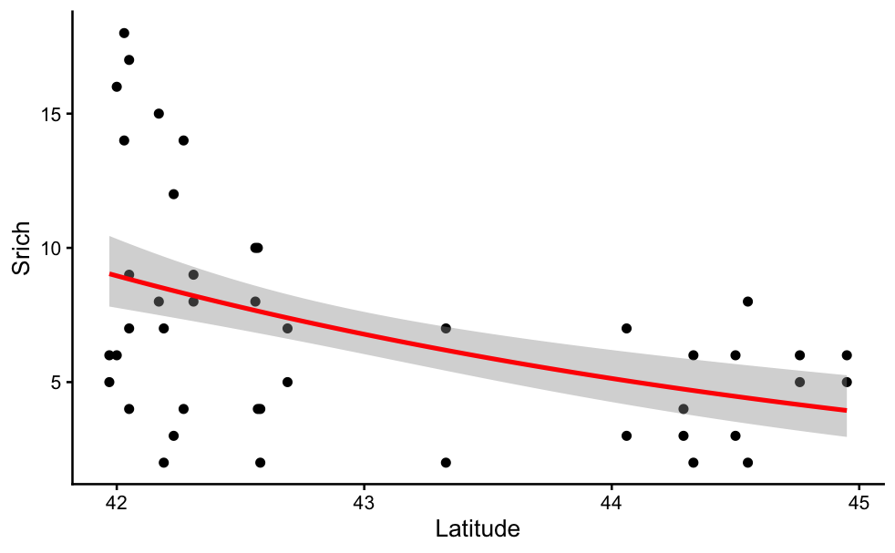